# Lecture 1：実証IO / quantitative marketingへようこそ

コース全体の地図と予測・因果・反実仮想｜計量経済学II

Kei Ikegami

## 今日の流れ（90分）

| 時間 | 内容 |
| --- | --- |
| 10分 | ガイダンス（シラバス・成績評価・課題） |
| 12分 | 計量経済学Iの復習：3ステップとシミュレーション |
| 8分 | 分野の整理：実証IO / quantitative marketing と4つの問い |
| 20分 | Rシミュレーション1：広告費と売上の罠 |
| 20分 | Rシミュレーション2：値上げすると販売数量が増える？ |
| 15分 | 反実仮想とは何か |
| 5分 | まとめ・宿題・次回予告 |

# ガイダンス

## この講義は何の授業か

- **計量経済学Iの続編**。OLS・固定効果・DiD・IV・RDDという道具は揃った
- 計量IIではその道具を使って、**実証産業組織論（IO）/ quantitative marketing** の基礎を学ぶ
- 一言で言えば：**データを使って、企業や政策当局の意思決定を支える**授業
- 公開講座として**企業のデータ分析担当者**も多数受講 → 例はPOS・ECログ・広告ログなど企業データ中心

## コースを貫く4つの問い

企業・政策当局の意思決定は、突き詰めると次の4つに集約できる：

1. **(a) 需要と代替性を知る**：値上げしたら売上はどれくらい減る？ 競合とどれくらい代替的？
2. **(b) 施策の因果効果を知る**：この広告キャンペーン、本当に売上を増やした？
3. **(c) 顧客の異質性と価値を知る**：誰が優良顧客か？ 顧客生涯価値（CLV）は？
4. **(d) 最適に配分・価格付けする**：誰にクーポンを配る？ いつ・いくらで値付けする？

## 4つの問いと各回の対応

| 問い | 対応する回 |
| --- | --- |
| (a) 需要と代替性 | 第2回 logit需要、第3回 nested logit・価格内生性、第4回 random coefficient・合併分析 |
| (b) 施策の因果効果 | 第7回 属性のランダム化、第10回 施策の実験評価 |
| (c) 顧客の異質性と価値 | 第6回 個人の履歴、第8〜9回 階層ベイズ、第11回 BG/NBD・CLV |
| (d) 最適化 | 第10回 ターゲティング、第13〜14回 動学的離散選択、第15回 dynamic pricing |

- 第5回・第12回は**ゲスト講義**（公正取引委員会の実務、企業エコノミストの実務）

## 成績評価

- **Coding課題：40%**
  - データ分析課題を4回。需要推定・実験・顧客分析などの実装と結果の解釈
  - 手を動かせば2〜4時間で終わる分量。ヒントも用意する
- **査読レポート：30%**
  - Reading listから論文を2本選び、問い・識別戦略・データ・貢献・限界・改善案を整理
- **期末レポート：30%**
  - Research proposal。講義の手法を使った実証研究の問いを自分で設計する

## 教材と進め方

- **主教材**：上武・遠山・若森・渡辺『実証ビジネス・エコノミクス』日本評論社
- 補助教材：Train (2009) *Discrete Choice Methods with Simulation*、Kohavi, Tang and Xu (2020)（A/Bテスト）
- 毎回：**講義ノート（詳細版・コード付き）＋スライド**。第2回以降は冒頭に前回の復習クイズ
- 言語は**R**。データは配布しない——**全データを自分のシミュレーションで作る**

「モデルを書けばシミュレーションできる。シミュレーションできれば推定量の性質を実験で確かめられる」——計量Iの哲学をこのコースでも貫く。

# 計量経済学Iの復習

## 今日押さえたいこと

1. 計量Iの「**識別・推定・推論**」の3ステップと「**モデル＝条件付き分布の束**」をおさらいする
2. 実証IO・quantitative marketingという分野と、**4つの問い**との対応を頭に入れる
3. シミュレーションで「**予測」と「因果」がまったく別のタスク**であることを体感する
4. 「**反実仮想（counterfactual）**」の中身を明確にし、構造推定の見取り図を持つ

## 計量Iで揃えた道具

- **一般の推定・推論の道具**：OLS（単回帰・重回帰）、ロバスト標準誤差、$t$検定・信頼区間。これらだけで係数が因果効果になるわけではない
- **因果効果の識別戦略**：ランダム化、固定効果、DiD、操作変数法（2SLS）、RDD。それぞれの識別仮定が成り立つときに因果的に解釈できる
- **因果効果の定義**：潜在アウトカムの枠組み

計量IIはこの続き。ただし「測る」だけでなく、**モデルで「もしこうしていたら」を計算する**ところまで踏み込む。

## まずは：統計モデル＝条件付き分布の束

- 予測の出発点：**統計モデルとは、観測変数の条件付き分布の束である**
- 例：価格 $p$ などを条件とした需要 $q$ の分布 $P(q \mid p, \ldots)$ を指定する
- 「束」＝条件の値ごとに分布が1つずつ定まっている
- 介入・均衡を扱う構造モデルでは、さらに**何を外から動かすか**と**政策変更後も保つ行動・均衡条件**を置く

条件付き分布として書き下せれば、**コンピュータの中でそのモデルに従うデータを生成できる**。

## 実証分析の3ステップ

1. **識別（identification）**：無限にデータがあれば、知りたいパラメータは一意に定まるか。定まるための**仮定**は何か
2. **推定（estimation）**：手元の**有限データ**から、そのパラメータの値をどう計算するか
3. **推論（inference）**：推定値の**誤差の大きさ**をどう測り、どこまで確信してよいかをどう表現するか

計量IIでも、新しいモデルが出てくるたびにこの3ステップで整理する。

## シミュレーションは検証の道具だった

計量Iでのシミュレーションの使い道：

- モデル（DGP）をコードで書き、真のパラメータでデータを生成する
- 推定量が**真値を回収できるか**を実験で確かめる
- 標準誤差や信頼区間の妥当性を**モンテカルロ**で検証する

つまり「**推定量の性質を確認するための道具**」だった。

## 計量IIでは：シミュレーションが目標になる

- 計量IIでは、**シミュレーションそのものが最終目標**に変わる
- モデルのパラメータを推定したら、そのモデルで**まだ起きていない状況**を計算機の中に作る
  - もし価格を10%上げたら？
  - もしこの2社が合併したら？
  - もし広告予算を倍にしたら？

これが**構造推定（structural estimation）**の核心：反実仮想シミュレーションのためにモデルのパラメータを推定する。このコース全15回（ゲスト2回を含む）を貫くテーマ。

## 復習：潜在アウトカムと根本問題

処置 $D_i \in \{0,1\}$、潜在アウトカム $Y_i(1), Y_i(0)$ とすると、観測されるのは

$$Y_i = D_i Y_i(1) + (1 - D_i) Y_i(0)$$

平均処置効果は

$$\tau = E[Y_i(1) - Y_i(0)]$$

- どの個体も $Y_i(1)$ と $Y_i(0)$ の**両方は観測できない**——因果推論の根本問題
- 計量Iの手法（RCT・FE・DiD・IV・RDD）はすべてこの問題を回避する工夫だった
- 反実仮想シミュレーションも同じ問題への対処：**観測されない側をモデルで埋める**

# 分野の整理

## この分野、いくつかの名前で呼ばれる

- **実証産業組織論（empirical IO）**：価格設定・製品差別化・参入退出・合併といった市場構造を、需要と供給の**構造モデル**で分析。独占禁止政策（合併審査）と結びつきが強い
- **quantitative marketing**：消費者の購買行動（ブランド選択・購入タイミング・数量）をモデル化し、価格・広告・品揃え・CRMに応用
- **実証ビジネス・エコノミクス**：上の2つを包含する、「データで企業の意思決定を支援する」実務的な分析全般

## 境界線はない：道具を共有する隣接分野

- 3分野は**同じ道具**を共有する：離散選択モデル・最尤法・因果推論
- このコースでは便宜上「**実証IO / quantitative marketing**」とまとめて呼ぶ
- 近年は多くの企業が経済学PhDを「データサイエンティスト」「エコノミスト」として採用
  - Amazon・Uber・Airbnbなどでの経済学者の役割：Athey and Luca (2019)
- この講義で学ぶ内容は、まさにその実務と直結している

## 実務では、依頼はこう降ってくる

- 「新製品Xを出したら、既存製品Y・Zからどれくらい食われるか教えて」→ **(a) 需要と代替性**
- 「先月のテレビCM、本当に効果あったんですか？」→ **(b) 施策の因果効果**
- 「解約しそうな顧客を先に見つけて、リテンション施策を打ちたい」→ **(c) 顧客の異質性**
- 「この夏のセール、どの商品をどれだけ値下げすれば利益最大？」→ **(d) 最適化**

依頼は「これは需要分析です」とラベル付きで来ない。**曖昧な依頼を4つの問いに翻訳する力**こそ、実務で最初に鍛えられる勘所。

# Rシミュレーション1：広告費と売上の罠

## 状況設定：広告費が多い店ほど売上が高い

- ある小売チェーン。店舗ごとの**月間広告費**と**月間売上**のデータが手に入った
- 散布図を描くと、広告費が多い店ほど売上が高い、綺麗な右上がり

> ここから「広告費を増やせば売上が増える」と結論してよいか？
- 答えを知るには、**データがどう生まれたか（DGP）**を考える必要がある

## DGPを考える：地力という交絡

こういう世界を考える：

- 立地が良く接客力もある「**地力（quality）の強い店舗**」ほど、本部が広告予算を多めに配分する
- 地力が強い店舗は、広告を出そうが出すまいが売上が高い
- つまり**観測されない地力が、広告費と売上の両方に影響**している

これは計量Iで学んだ**交絡（confounding）**そのもの。

## DGPをコードに落とす

売上のモデル：地力の効果（0.4）は大きく、広告の真の効果（0.002）は小さい。

$$\log(\mathrm{sales}_i) = 5.0 + 0.4 \cdot \mathrm{quality}_i + 0.002 \cdot \mathrm{ad}_i + u_i$$

```r
n_stores <- 300

quality  <- rnorm(n_stores, mean = 0, sd = 1)     # 店舗の地力（観測されない）
ad_spend <- 100 + 30 * quality +                  # 地力が高い店ほど広告費が多い
  rnorm(n_stores, mean = 0, sd = 15)
ad_spend <- pmax(ad_spend, 10)

true_beta_ad      <- 0.002   # 広告の真の効果：1万円で売上(log)が0.2%増える程度
true_beta_quality <- 0.4     # 地力の効果：大きい（交絡の源泉）
```

## 散布図：一見、強い正の相関

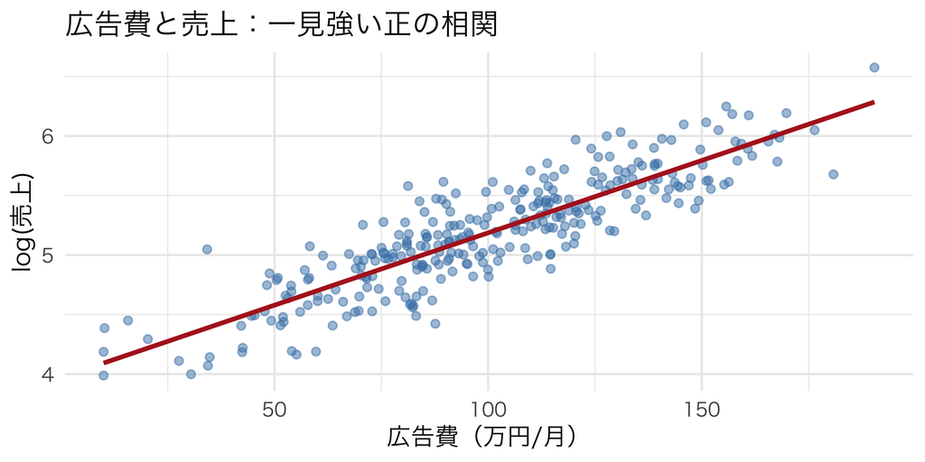

図 1

- 回帰直線は右上がり。広告が売上を大きく押し上げているように**見える**
- しかし我々はDGPを知っている：広告の真の効果は小さい

## 素朴なOLSは広告効果を過大評価する

| モデル | 広告費の係数 |
| --- | --- |
| 素朴なOLS（ad_spendのみ） | 0.01215 |
| 地力込みOLS（quality をコントロール） | 0.00225 |
| 真の値 | 0.00200 |

- 素朴なOLS：広告費が**地力の効果まで「代わりに」拾う** → 係数が真値の数倍
- 地力をコントロールすれば真値に近づく——が、実データでは地力は観測できない

## 図の前に、バイアスの向きを予想する

qualityを落とした単回帰では：

$$\operatorname{plim}\hat\beta_{\mathrm{short}}
=\beta_{\mathrm{ad}}+\beta_q
\frac{\operatorname{Cov}(\mathrm{ad},\mathrm{quality})}
{\operatorname{Var}(\mathrm{ad})}$$

- このDGPでは $\beta_q>0$
- 本部は地力の強い店ほど広告を多く配るので $\operatorname{Cov}(\mathrm{ad},\mathrm{quality})>0$

→ 欠落変数バイアスは**上向き**。推定結果はこの予想の答え合わせ。

## この分析、どこがまずい？

素朴な散布図と回帰直線だけを見て「広告は効果がある」と報告する——実務で最もよくある誤りの1つ。**相関が強いことと、その変数を動かせば結果が変わることは、まったく別の主張**である。

- 前者は「**予測**」のタスク、後者は「**因果（介入）**」のタスク
- ここからが本題：**同じモデル**が、予測では当たり、介入では大外しすることを見る

## 予測タスク：ホールドアウトで検証

データを学習用200店舗・検証用100店舗に分け、**広告費だけの素朴なモデル**で検証用の売上を予測する。

| 手法 | ホールドアウトR2 |
| --- | --- |
| 広告費を使う予測モデル | 0.718 |
| ベースライン（平均のみ） | -0.006 |

- 広告費を使うモデルは、平均だけのベースラインよりはるかに当てはまりが良い

## 予測は当たる：45度線の周りに集まる

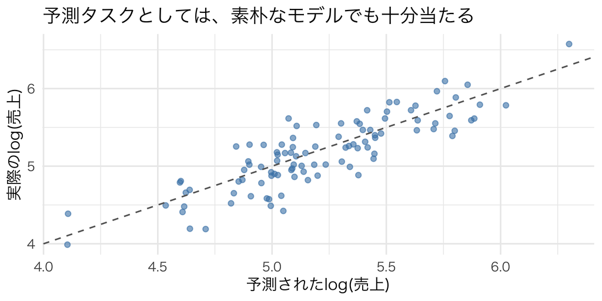

図 2

- 「来月の売上を当てる」目的なら、素朴なモデルは**十分役に立つ**
- 本部の予算配分方針が変わらない限り、地力と広告費の相関はこれからも続くから

## 介入「広告費を2倍」を計算する

「広告費を2倍にしたら売上は？」を、(i) 真のDGP と (ii) 素朴なOLS の両方で計算：

```r
new_ad_spend <- store_df$ad_spend * 2   # 介入：地力はそのまま、広告費だけ2倍

true_effect <- true_beta_ad * (new_ad_spend - store_df$ad_spend)  # 真の効果
ols_effect  <- beta_short   * (new_ad_spend - store_df$ad_spend)  # 素朴なOLSの予測
```

| 手法 | log売上の平均変化 | 店舗別の売上変化率の平均（%） |
| --- | --- | --- |
| 真の効果 | 0.201 | 22.506 |
| 素朴なOLSによる予測 | 1.219 | 268.323 |

## 同じモデルなのに：予測は当たり、介入は外れる

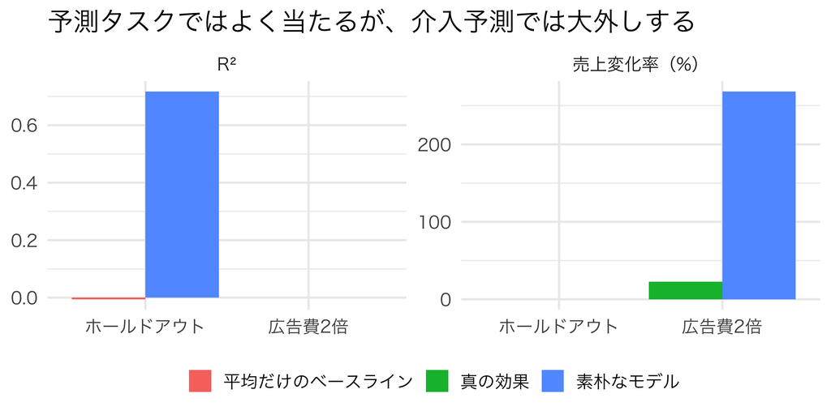

図 3

## ここが核心

**同じ変数、同じ回帰式でも、「予測」と「因果（介入効果）」はまったく別のタスクである。**

- 予測：既存の相関構造がこれからも続くと仮定して、未観測の値を当てる。相関で十分
- 介入：相関構造そのものを壊す操作。**相関がどこから来ているか（交絡は何か）**を明示的に考える必要がある

この区別は、このコース全体を通じて何度も立ち返る。

# Rシミュレーション2：値上げすると販売数量が増える？

## 状況設定：価格弾力性を推定したい

- ある店舗の**週次の価格と販売数量**のデータ
- log-log回帰（弾力性推定の定番）をかけると、価格の係数が**プラス**に出た

> 「値上げすると販売数量が増える」——そんなことがあるか？
- 常識的には奇妙。しかし実データでは**頻繁に起きる**
- 何が起きているのか、DGPから考える

## DGP：繁忙期には強気の価格設定

**需要が盛り上がっている時期には、店も強気の価格を付ける**という世界：

$$\log q_t = \log(500) - 1.2 \{\log p_t-\log(1000)\} + 0.8 d_t + u_t$$

需要ショック $d_t$ は価格にも入り込む：$\log p_t = \log(1000) + 0.3 \cdot d_t + e_t$

```r
n_weeks <- 200
demand_shock <- rnorm(n_weeks, mean = 0, sd = 1)  # 繁忙期・季節性（観測しにくい）

true_elasticity <- -1.2   # 真の価格弾力性：普通の右下がりの需要曲線
gamma_price     <- 0.3    # 繁忙期ほど強気の価格設定（内生性の源泉）
phi_demand      <- 0.8    # 需要ショックが数量に与える直接効果
```

## 散布図：右上がりに見える

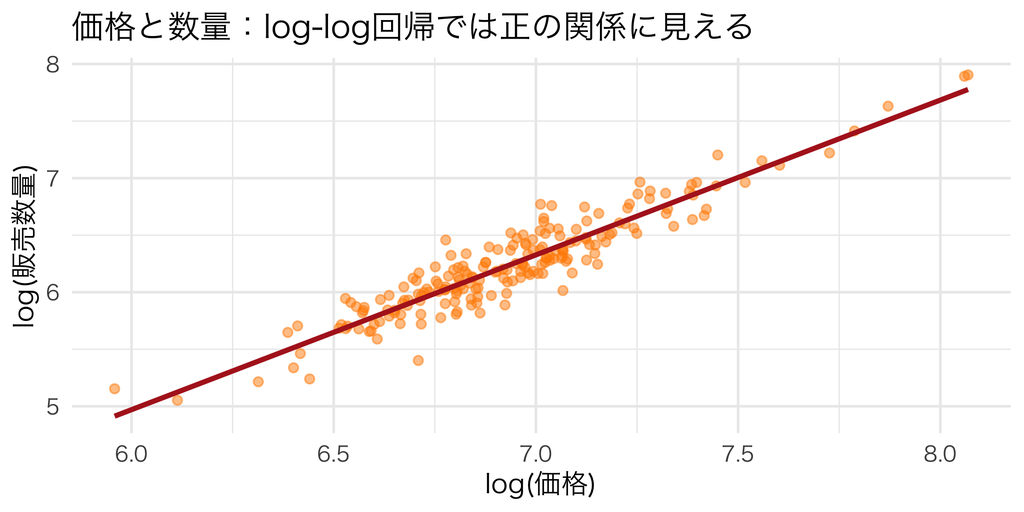

図 4

- 価格が高い週ほど数量も多い、という見た目
- 真の需要曲線は右下がり（弾力性 -1.2）のはずなのに

## OLS推定：符号まで逆転する

|  | 手法 | 価格弾力性 |
| --- | --- | --- |
| log_price | log-log OLS推定値 | 1.357 |
|  | 真の弾力性 | -1.200 |

- 推定された価格係数は**プラス**。真値は -1.2 なのに、**符号すら逆**
- 需要ショックが価格と数量を同時に押し上げるために起きる——**価格の内生性（price endogeneity）**

## 真の需要曲線とOLS回帰直線は逆を向く

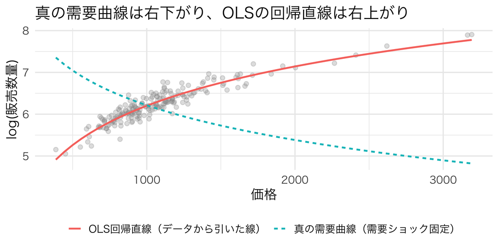

図 5

## ビジネスの現場で：繁忙期の値上げの錯覚

- 「繁忙期に値上げしたのに販売数量が伸びた。**値上げが数量を伸ばした**のでは？」
- 実際には**繁忙期の需要の強さ**が価格と数量の両方を押し上げているだけ
- 同じ繁忙期に値上げしなければ、数量は**もっと**伸びていたかもしれない

「値上げしても売れる」と「値上げが数量を増やした」は別物。この錯覚は価格改定の現場で頻繁に起きる。

## 反実仮想「価格+10%」を計算する

「価格を10%上げたら数量はどう変わるか」を、(i) 真のモデル と (ii) OLSモデル で計算：

| 手法 | 価格+10%のときの需要変化（%） |
| --- | --- |
| 真のモデル | -10.81 |
| OLSモデル | 13.81 |

- 真のモデル：数量は1割程度**減る**（弾力性 -1.2 の普通の反応）
- OLSモデル：数量が**増える**という、教科書をひっくり返す結論

## 売上で見ても結論が正反対

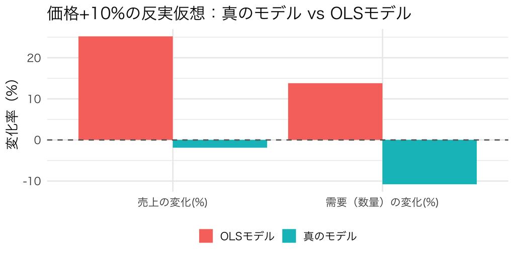

図 6

- 真のモデル：数量は減り、売上もわずかに減る（弾力性がほぼ1に近いため）
- OLSモデル：数量も売上も大きく増えるという**真逆の結論**

## これが価格の内生性：次回以降の主役

**価格の内生性**は、需要推定における最大の技術的難所。価格は企業が需要を見ながら決める変数なので、需要ショックと相関するのが**むしろ普通**。

- 第3回で本格的に扱う：操作変数法の応用・コストシフターの利用
- 計量Iで学んだ**2SLSの考え方がそのまま使える**ことを確認していく

# 反実仮想とは何か

## 反実仮想（counterfactual）の定義

- 「広告費を2倍にしたら」「価格を10%上げたら」——今日計算してきたのが、まさに**反実仮想**
- 定義：**もしあの時、実際に起きたこととは違う選択をしていたら、結果はどうなっていたか**を、モデルを使って計算すること
- 潜在アウトカムの言葉で言えば：**観測されなかった側の潜在アウトカム**を、モデルで埋め合わせる作業

## 計量Iの道具が答えられる範囲

- DiD・IV・RDDも、広い意味では反実仮想を扱っていた（「処置がなかったら」の推定）
- 研究デザインが最も説得力を持つのは「**観測された処置・共変量の支持範囲に近い**」問い
  - 5%値上げした店舗のデータがあれば、DiDで「5%値上げの効果」は測れる
  - しかし「**50%値上げしたら？**」「**まったく新しい価格帯なら？**」には答えに窮する

## 構造モデルなら、データの外側も計算できる

- 需要関数・効用関数といった**構造モデル**を推定すれば、データに存在しない価格・商品構成でも、**モデルの数式に従って**結果を計算できる

**構造推定（structural estimation）とは、反実仮想シミュレーションをするためにモデルのパラメータを推定する作業である。**

- ただし遠い外挿ほど、**関数形・政策不変性・均衡仮定**への依存が強い。計算可能＝信頼できる、ではない

## このコースで扱う反実仮想の例

- **合併審査**（第4〜5回）：2社が合併したら、統合後の会社は価格をどう変えるか
  - 需要の代替性 × 供給側の価格設定モデル → 合併後の均衡価格をシミュレーション
  - 公正取引委員会などの独占禁止当局が**実際に行っている分析**そのもの
- **価格最適化**（第15回）：将来の需要変動・在庫を織り込み、いつ・いくらで値付けすれば利益最大かを動的計画法で計算

## 整理：予測・因果・反実仮想

- **予測**：既存の相関構造で未観測の値を当てる。因果関係は不要だが、予測先でも相関構造が安定している必要
- **因果効果**：ある1つの施策について「した場合としなかった場合の差」を測る。処置は**データの中で実際に起きたもの**に限られがち
- **反実仮想／構造推定**：モデルを推定し、**データに存在しない状況**の結果を計算する

3つは排他的ではない：因果推論の道具は構造モデルの識別・推定に使われる（第3回のIV需要推定が代表例）。

このコースは「予測」から「因果」を経て「反実仮想」へと視野を広げていく旅である。

## 問いを一段ずつ仕分ける

| タスク | 追加で必要になるもの |
| --- | --- |
| 予測 | ホールドアウト精度＋分布の安定性 |
| 支持範囲内の因果効果 | 反実仮想を作る識別戦略 |
| 構造的反実仮想 | 行動パラメータ＋不変性・均衡仮定 |
| 最適化 | 反実仮想モデル＋目的関数・制約 |

「価格を下げたら？」だけではタスクは決まらない。**何の意思決定に使う数字か**まで聞く。

## A/Bテストできない意思決定は多い

実験は最強の道具だが、使えない意思決定も多い：

- **全社的な値上げ**：店舗・顧客で価格を出し分けると不公平感・炎上リスク
- **テレビCM・マス広告**：地域単位でしか出し分けられず、綺麗な実験にならない
- **店舗の大規模改装**：コストが大きすぎてランダム割当は非現実的
- **企業の合併**：「合併する世界としない世界」を両方試すことは不可能

→ そこで**計量Iで学んだ観察データの因果推論**と**構造モデルの反実仮想**（第3〜5回・第15回）が主要な武器になる

# まとめ

## 今日のまとめ

- 計量IIの土台は計量Iと同じ：**識別・推定・推論**の3ステップと**モデル＝条件付き分布の束**
- ただしシミュレーションの役割が昇格：検証の道具 → **反実仮想の計算そのものが最終目標**（＝構造推定）
- 企業の意思決定は4つの問いに整理できる：**需要・因果効果・顧客異質性・最適化**
- **予測と因果は別のタスク**：広告費モデルは予測では当たるが、介入予測では大外しする
- **価格の内生性**：繁忙期に価格も需要も上がるDGPでは、OLSの弾力性は符号まで逆転する
- A/Bテストできない意思決定では、観察データの因果推論と構造モデルの反実仮想が武器になる

## 宿題

- 計量Iの自分のノートを見返し、「識別・推定・推論」と「モデル＝条件付き分布の束」を自分の言葉で3行にまとめ直す
- 生成AIに「反実仮想とは何か、経済学の文脈で説明して」と聞き、今日の内容と比べる
- 自分の仕事（または身近な企業）で「A/Bテストができない意思決定」を1つ挙げ、どう分析できそうか考える
- **coding課題は `assignment1.qmd`**：今日の価格弾力性のシミュレーションを店舗パネルに拡張し、**2SLSで真の弾力性を回収**する練習

## 次回予告：離散選択モデルへ

- 「消費者が複数の選択肢から1つを選ぶ」状況を **random utility model（RUM）** として定式化する
- 有名な **logitモデル** の選択確率を導出する
- 計量Iで扱わなかった**最尤法（MLE）**を初めて学び、自作コードで推定する
- 価格弾力性・交差弾力性を計算し、プライシングの問いに答える

**Reading**：上武ほか (2025)『実証ビジネス・エコノミクス』第1〜2章、Train (2009) Chapters 2-3